# MigClim_Hippos

Julián Velasco

10/11/2021

La mayoría de estudios que han usado ENM/SDM para generar proyecciones a futuro bajo escenarios de cambio climático o de uso de suelo ignoran aspectos de historia de vida de las especies, particularmente limitaciones por dispersión y aspectos demográficos. Dependiendo de la fragmentación del hábitat y las capacidades de dispersión de las especies, estos supuestos suelen ser inadecuados y generan proyecciones con mucha incertidumbre.

En este ejercicio usaremos un modelo que fue conceptualizado en el 2009 por Robin Engler y Antoine Guisan llamado MigClim. El modelo fue utilizado para evaluar la distribución potencial futura de los hipopótamos invasores en Colombia que se encuentran en la cuenca del río Magdalena. El modelo permite integrar la tasa a la que el clima cambia, fragmentación del paisaje, capacidades de dispersión de las especies, y potencial reproductivo. MigClim está basado en autómatas celulares (von Neumann circa 1950), que es un modelo matemático y computacional de evolución en una serie de pasos discretos. En el caso particular de la modelación de nicho, los valores de favorabilidad (“suitability”) de cada celda evolucionan en el tiempo de acuerdo a una serie de reglas (e.g., cambio climático) y que están influenciadas por el vecindario de celdas. El modelo simula dispersión, colonización, crecimiento y extinción de una especie en el paisaje.

Para simular la distribución potencial de los hipopótamos invasores en Colombia necesitamos varios parámetros:

- Frecuencia de eventos de dispersión (años). Este indica el tiempo entre dos eventos de dispersión sucesivos.
- Distancia de dispersión (DispDist) (m).
- Máxima distancia de dispersión de larga distancia (LDD) (m).
- Frecuencia de LDD.
- Potencial reproductivo del pixel. Indica cuál es la probabilidad de que un pixel colonizado sea un pixel fuente e incremente con el tiempo.
- Barreras geográficas.
- Filtros (e.g., áreas urbanas o innaccesibles).

Antes de comenzar hay que instalar el paquete y es un poco tedioso. La versión que se usó para el artículo de Castelblanco-Martínez et al. (2020) es la 1.6.

```r
# Instalar paquetes

# primero instalar SDMTools
# install.packages("remotes")
# remotes::install_version("SDMTools", "1.1-221")

# luego instalar MigClim versión 1.6
# véase https://cran.r-project.org/src/contrib/Archive/MigClim/
# install_version("MigClim", version = "1.6", repos = "http://cran.us.r-project.org")

library(MigClim)
library(raster)

# Funciones para ver cuáles funciones y la ayuda de cada paquete
lsf.str("package:MigClim")
```

```
## MigClim.genClust : function (hsMap = "hsMap", barrier = "barrier", nrClusters = 4, nrIterations = 1,
##     threshold = 445, outFile = "out", initFile = "")
## MigClim.migrate : function (iniDist = "InitialDist", hsMap = "HSmap", rcThreshold = 0, envChgSteps = 1,
##     dispSteps = 1, dispKernel = c(1, 1), barrier = "", barrierType = "strong",
##     iniMatAge = 1, propaguleProd = c(1), lddFreq = 0, lddMinDist = NULL,
##     lddMaxDist = NULL, simulName = "MigClimTest", replicateNb = 1, overWrite = FALSE,
##     testMode = FALSE, fullOutput = FALSE, keepTempFiles = FALSE)
## MigClim.plot : function (asciiFile, outDir = "", fileFormat = "jpeg", fullOutput = FALSE)
## MigClim.userGuide : function ()
## MigClim.validate : function (validateFile = "Validation.txt", nrPoints = 0, simFile = "out1.asc",
##     nrClusters = 4)
```

```r
help(package = MigClim)
```

Vamos a cargar los datos pre-fabricados para ahorrar tiempo. Esta tabla de datos muestra para cada pixel en la región geográfica la presencia/ausencia (0-1) de los hipopótamos y los valores de favorabilidad (suitability) obtenidos de un ensamble de modelos. Los valores de favorabilidad fueron estandarizados de 0 a 1000. Hay una columna al final que indica si en la región un pixel determinado es accessible (1) o no (0).

Para ajustar el modelo hay que primero obtener los parámetros de los hipopótamos de la literatura.

Descargue los datos de aquí: https://www.dropbox.com/sh/btys7ucruafoemd/AAARkElKrvUqUeQbiaXlnP6na?dl=0

```r
# Cargar los datos pre-fabricados
MigClim.Data.v1 <- read.csv("./Datos/Dataset_Hippos_MigClim.csv", row.names = 1)
rounds <- round(MigClim.Data.v1[c(-1,-2)], digits = 0)
MigClim.Data.v1 <- cbind(MigClim.Data.v1[,c(1,2)], rounds)

# Explorar los datos
head(MigClim.Data.v1)
```

```
##           X        Y InitialDist hsmap1 hsmap2 hsmap3 hsmap4 hsmap5 hsmap6
## 1 -74.85417 11.10417           0    303    284    302    257    127    367
## 2 -74.81250 11.06250           0    378    390    305    257    128    362
## 3 -74.77083 11.06250           0    392    385    272    257    128    287
## 4 -74.89583 11.02083           0    418    183    236    325     99    224
## 5 -74.85417 11.02083           0    450    181    236    257     99    219
## 6 -74.81250 11.02083           0    600    189    236    257     99    219
##   hsmap7 hsmap8 hsmap9 hsmap10 hsmap11 hsmap12 hsmap13 hsmap14 hsmap15 hsmap16
## 1    253    199    222     222     100     337     185     268     179     284
## 2    258    155    286     225     130     341     165     269     183     223
## 3    263    155    286     225     130     341     165     269     183     223
## 4    260    158    290     175     132     226     137     268     126     226
## 5    191    155    286     172     130     272     134     268     126     222
## 6    191    155    286     145     130     223     147     268     126     222
##   hsmap17 hsmap18 hsmap19 hsmap20 hsmap21 hsmap22 hsmap23 hsmap24 hsmap25
```

[output cut: 62 more lines]

PRIMER PASO:

1. Crear un kernel de dispersión (dispKernel)

Distribución de probabilidad de la dispersión para un periodo de 95 años Uniforme - Aplanado. Asume que la dispersión es constante a través del tiempo.

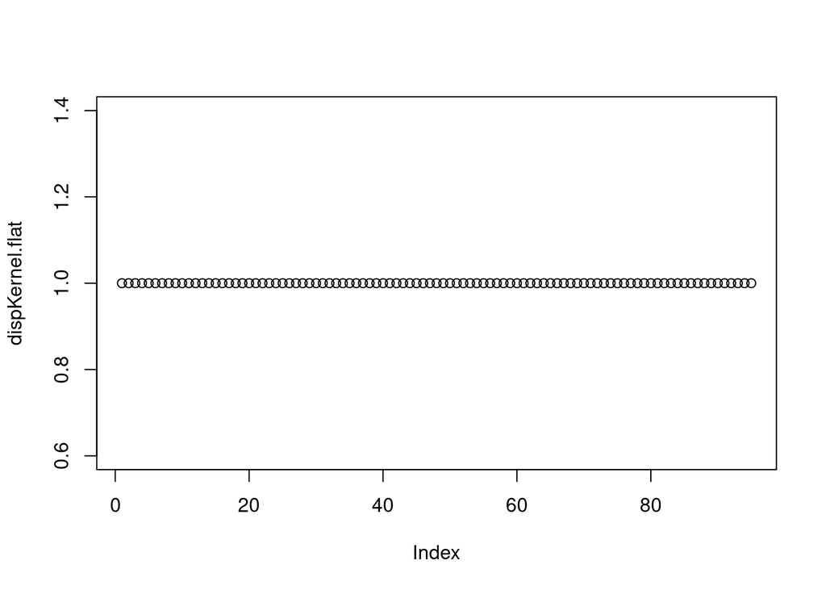

```r
dispKernel.flat <- runif(95, min=1, max=1)
plot(dispKernel.flat) # n1
```

Decaimiento exponencial en la probabilidad de dispersión a través de los pasos de dispersión (dispSteps) en un periodo de 95 años. Primero creamos una función que simule una distribución exponencial que vaya cayendo a través del tiempo (Y = Yo * Exp(-beta*t)).

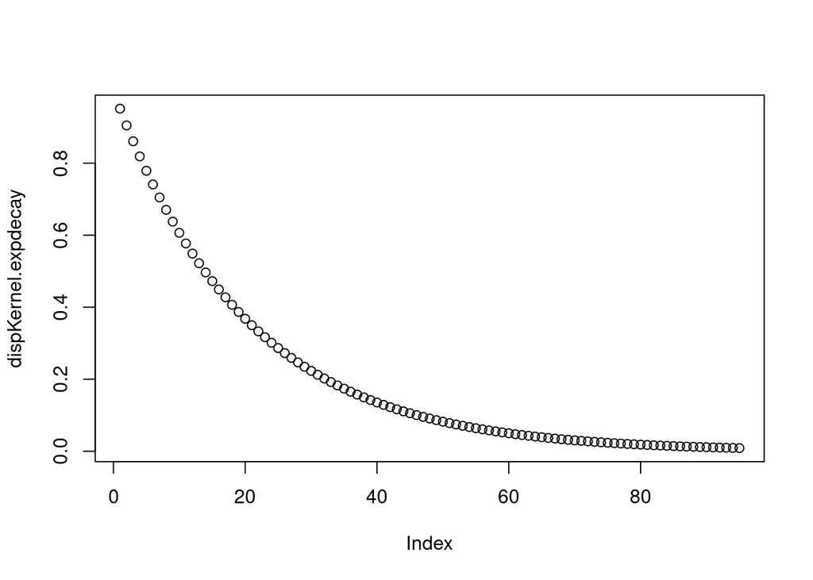

```r
# decaimiento exponencial en la probabilidad de dispersión
alpha <- 1 # dispersión inicial
beta <- -0.05 # tasa de decaimiento

n <- 95 # años
x <- seq(n) # secuencia de años
dispKernel.expdecay <- alpha * exp(beta * x)

plot(dispKernel.expdecay) # n2
```

Producción de propágulos (plantas) o crías (animales)

```r
propaguleProdProb <- c(0.02, 0.1, 0.3, 0.5, 0.9)

# Información reproductiva tomada de Tabla 1 (Castelblanco-Martínez et al 2020)
initMatAge=5 # Edad inicial de madurez sexual (hembras)
maxMatAge=43 # Edad máxima de madurez sexual (hembras)
```

Crearemos una distribución uniforme de la probabilidad de reproducción (entre 0.9 y 1) de los hipopótamos en función de la duración de la etapa reproductiva (43 años) una vez han colonizado una celda en particular.

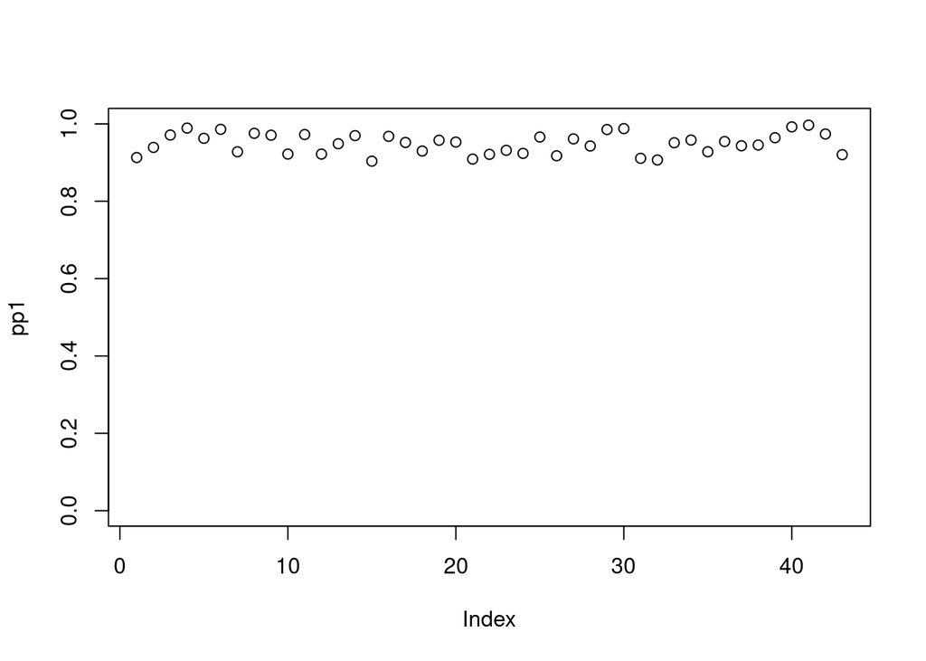

```r
# distribución aplanada o uniforme
pp1 <- runif(43, min=0.9, max=1)

plot(pp1, ylim=c(0,1))
```

Crearemos una distribución exponencial de la probabilidad de reproducción de los hipopótamos en función de la duración de la etapa reproductiva (43 años) una vez han colonizado una celda en particular.

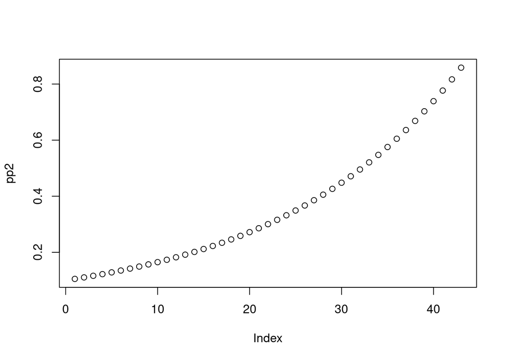

```r
# distribución exponencial
alpha <- 0.1 # probabilidad de reproducción apenas coloniza una celda
beta <- 0.05 # tasa de crecimiento

n <- 43 # años
x <- seq(n) # secuencia de años
pp2 <- alpha * exp(beta * x) # n2

plot(pp2)
```

Ahora vamos a simular las probabilidades de dispersión, colonización, y extinción de los hipopótamos en la región de la cuenca del Madgalena. Se crearon cuatro escenarios. Vamos a generar uno solo y les queda de tarea los otros tres.

PRIMER ESCENARIO:

Probabilidad de dispersión uniforme a través del tiempo (dispKernel.flat) y probabilidad de reproducción exponencial de los hipopótamos una vez colonicen una celda (pp2), y una barrera geográfica fuerte.

Correr la simulación con 1 repetición:

```r
n1 <- MigClim.migrate (iniDist=MigClim.Data.v1[,1:3],
                         hsMap=MigClim.Data.v1[,4:98], rcThreshold=64,
                         envChgSteps=95, dispSteps=95, dispKernel=dispKernel.flat,
                         barrier=MigClim.Data.v1[,99], barrierType="strong",
                           iniMatAge=5, propaguleProd=pp2,
                         lddFreq=0.01, lddMinDist=96, lddMaxDist=1000,
                         simulName="SimA", replicateNb=1, overWrite=TRUE,
                         testMode=FALSE, fullOutput=TRUE, keepTempFiles=FALSE)
```

```
## Converting data to ascii grid format...
## Starting simulation for  SimA ...
## Running MigClim simulation SimA.
##   1...
##   2...
##   3...
##   4...
##   5...
##   6...
##   7...
##   8...
##   9...
##   10...
##   11...
##   12...
##   13...
##   14...
##   15...
##   16...
##   17...
##   18...
##   19...
##   20...
##   21...
##   22...
##   23...
##   24...
##   25...
##   26...
##   27...
##   28...
##   29...
##   30...
##   31...
##   32...
##   33...
##   34...
##   35...
##   36...
##   37...
```

[output cut: 45 more lines]

```
##   83...
##   84...
##   85...
##   86...
##   87...
##   88...
##   89...
##   90...
##   91...
##   92...
##   93...
##   94...
##   95...
## All dispersal steps completed. Final output in progress...
## Simulation SimA completed successfully. Outputs stored in /home2/Dropbox/Curso/Ejercicios_R/MigClim/SimA
```

Vamos a generar la figura del raster final

[output not shown]

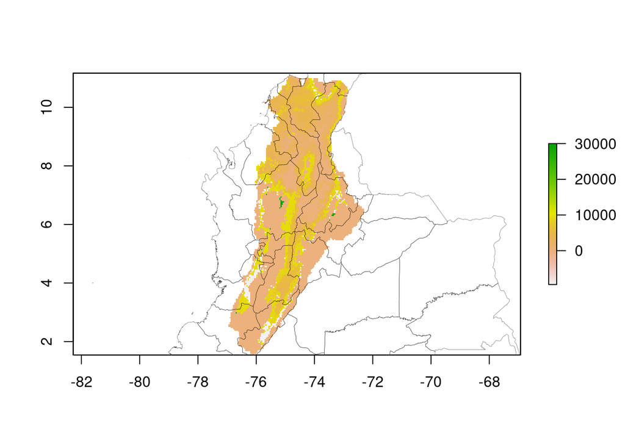

```r
# Definir el esquema de colores
cols <- c("gray89", "blue", "green")

# reclasificar
run1.r <- reclassify(run1,reclass_m)
run1.r2 <- reclassify(run1,reclass_m2)
```

Primer mapa

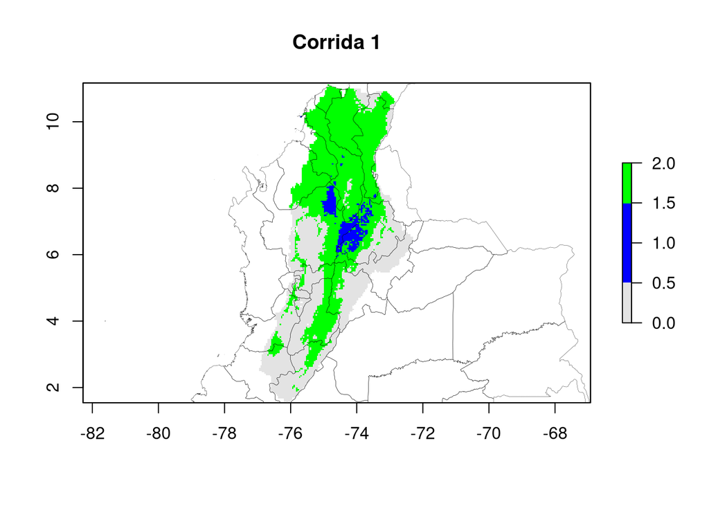

```r
# graficar
plot(run1.r, col=cols, legend=TRUE, main="Corrida 1")
plot(colombia, add=T, lwd=0.2)
```

Segundo mapa

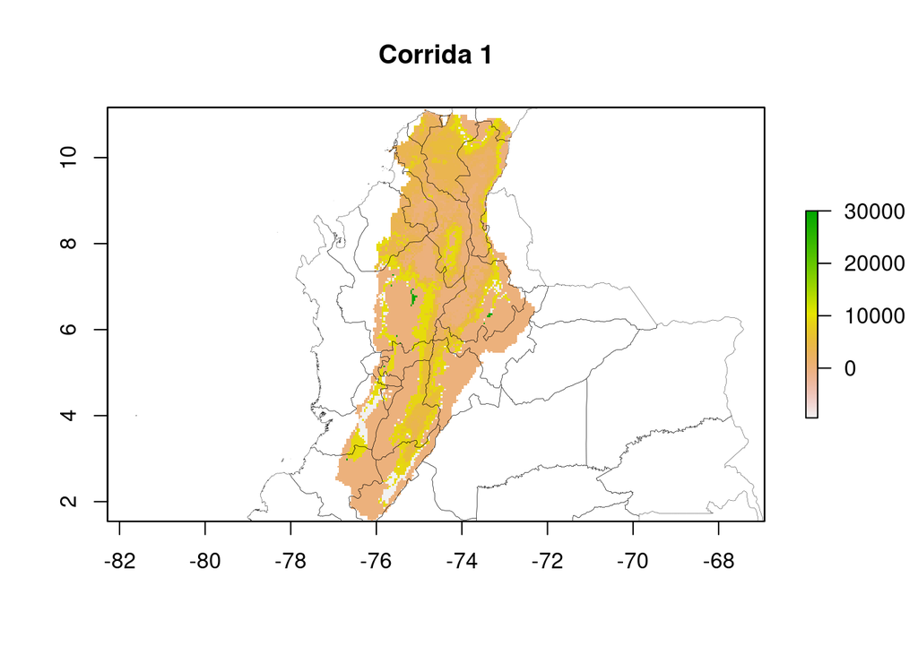

```r
# graficar
plot(run1.r2, legend=TRUE, main="Corrida 1")
plot(colombia, add=T, lwd=0.2)
```

La tarea consiste en probar varias combinaciones de parámetros:

Kernels de dispersión: 1) dispKernel.flat 2) dispKernel.expdecay

Probabilidad de producción de propágulos/crías 1) pp1: uniforme 2) pp2: exponencial

Frecuencia de eventos de dispersión de larga distancia 1) 0.01 2) 0.1 3) 0.5

Tipos de barreras de dispersión 1) fuerte (strong) 2) débil (weak)

A jugar!